# Anushka_Jadhav_NLP_Support_Ticket_Categorization_Full_Code

## **Problem Statement**

### Business Context

In today's dynamic business landscape, organizations are increasingly recognizing the pivotal role customer feedback plays in shaping the trajectory of their products and services. The ability to swiftly and effectively respond to customer input not only fosters enhanced customer experiences but also serves as a catalyst for growth, prolonged customer engagement, and the nurturing of lifetime value relationships. As a dedicated Product Manager or Product Analyst, staying attuned to the voice of your customers is not just a best practice; it's a strategic imperative.

While your organization may be inundated with a wealth of customer-generated feedback and support tickets, your role entails much more than just processing these inputs. To make your efforts in managing customer experience and expectations truly impactful, you need a structured approach – a method that allows you to discern the most pressing issues, set priorities, and allocate resources judiciously. One of the most effective strategies at your disposal is to harness the power of Support Ticket Categorization.

### Objective

Develop an advanced support ticket categorization system that accurately classifies incoming tickets, assigns relevant tags based on their content, implements mechanisms and generate the first response based on the sentiment for prioritizing tickets for prompt resolution.

## **Sample of Expected Output**

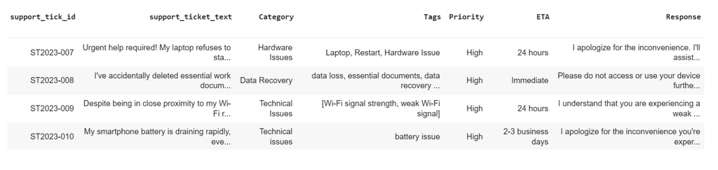

## **Installing and Importing Necessary Libraries and Dependencies**

```python
# Import libraries for data manipulation and utilities
import re
import time
import json
import random
import numpy as np
import pandas as pd

# Import libraries for error handling
import warnings

# Import libraries for data visualization
import matplotlib.pyplot as plt
import seaborn as sns
```

```python
# Installation for GPU llama-cpp-python
# uncomment and run the following code in case GPU is being used

#!CMAKE_ARGS="-DLLAMA_CUBLAS=on" FORCE_CMAKE=1 pip install llama-cpp-python==0.1.85 --force-reinstall --no-cache-dir -q
```

```python
# Installation for CPU llama-cpp-python
# uncomment and run the following code in case GPU is not being used

!CMAKE_ARGS="-DLLAMA_CUBLAS=off" FORCE_CMAKE=1 pip install llama-cpp-python==0.1.85 --force-reinstall --no-cache-dir -q
```

[output not shown]

**Note** : There may be an error related to a dependency issue thrown by the pip package. This can be ignored as it will not impact the execution of the code.

```python
# For downloading the models from HF Hub
#!pip install huggingface_hub==0.20.3 pandas==1.5.3 -q

!pip install huggingface_hub==0.20.3 pandas==2.0.3 fastapi==0.110.2 --no-cache-dir -q
```

[output not shown]

```python
# Import libraries from hugging face hub module
import huggingface_hub as hf_hub_download
from huggingface_hub import *

# Import libraries from llama module
import llama_cpp as Llama
from llama_cpp import *
```

```python
# Apply settings

# Ignore warnings
warnings.filterwarnings('ignore')

# Set limit for the displayed columns in a DataFrame
pd.set_option('display.max_columns', 50)

# Set precision of floating numbers to 5 decimal points
pd.set_option('display.float_format', lambda x: '%.5f' % x)

# Set fixed seed for random number generators
random_state = 1

random.seed(random_state)
np.random.seed(random_state)
```

## **Loading the Data**

```python
from google.colab import drive
drive.mount('/content/drive')
```

```python
# Read the CSV file.
data = pd.read_csv("/content/drive/MyDrive/AI ML PG Programme/NLP/Project/Support_ticket_text_data_mid_term.csv")
```

## **Data Overview**

### Checking the first 5 rows of the data

```python
# Check the first 5 rows of the data
data.head()
```

|  | support_tick_id | support_ticket_text |
| --- | --- | --- |
| 0 | ST2023-006 | My internet connection has significantly slowe... |
| 1 | ST2023-007 | Urgent help required! My laptop refuses to sta... |
| 2 | ST2023-008 | I've accidentally deleted essential work docum... |
| 3 | ST2023-009 | Despite being in close proximity to my Wi-Fi r... |
| 4 | ST2023-010 | My smartphone battery is draining rapidly, eve... |

*Observations*

- The support_tick_id contains reference numbers to track the issues logged by the users.
- The support_ticket_text contains issues reported by the users.

### Checking summary of the data

```python
# Display the summary of the dataset
data.info()
```

```
<class 'pandas.core.frame.DataFrame'>
RangeIndex: 21 entries, 0 to 20
Data columns (total 2 columns):
 #   Column               Non-Null Count  Dtype
---  ------               --------------  -----
 0   support_tick_id      21 non-null     object
 1   support_ticket_text  21 non-null     object
dtypes: object(2)
memory usage: 464.0+ bytes
```

*Observations*

- The dataset contains 21 rows with 2 columns.
- The size of the DataFrame is 464 Bytes.
- There is only 1 data type in the dataset:
- object (2): support_tick_id, support_ticket_text

### Checking the shape of the data

```python
# Check the shape of the data
data.shape
```

```
(21, 2)
```

*Observation*

The data contains 21 rows and 2 columns

### Checking the missing values in the data

```python
# Check for missing values in the data
data.isna().sum()
```

|  | 0 |
| --- | --- |
| support_tick_id | 0 |
| support_ticket_text | 0 |

**dtype:** int64

*Observations*

There are no missing values

### Checking the duplicates in the data

```python
# Display how many duplicate records are present in the dataset
data.duplicated().sum()
```

```
0
```

```python
# Display how many duplicate records are present in the dataset
data['support_tick_id'].duplicated().sum()
```

```
0
```

*Observations*

There are no duplicate values in the dataset.

## **Model Building**

### Loading the model

```python
model_name_or_path = "TheBloke/Mistral-7B-Instruct-v0.2-GGUF"
model_basename = "mistral-7b-instruct-v0.2.Q6_K.gguf"
```

```python
model_path = hf_hub_download(
    repo_id=model_name_or_path,
    filename=model_basename
)
```

```python
# uncomment and run the following code in case GPU is being used

# llm = Llama(
#      model_path=model_path,
#      n_ctx=1024, # Context window
#  )
```

```python
# run the following code in case GPU is not being used

llm = Llama(
    model_path=model_path,
    n_ctx=1024, # Context window
    #n_cores=-2 # Number of CPU cores to use
)
```

```
AVX = 1 | AVX2 = 1 | AVX512 = 0 | AVX512_VBMI = 0 | AVX512_VNNI = 0 | FMA = 1 | NEON = 0 | ARM_FMA = 0 | F16C = 1 | FP16_VA = 0 | WASM_SIMD = 0 | BLAS = 0 | SSE3 = 1 | SSSE3 = 1 | VSX = 0 |
```

**Observations:**

### Utility functions

```python
# function to parse the JSON output from the model
def extract_json_data(json_str):
    try:
        # Find the indices of the opening and closing curly braces
        json_start = json_str.find('{')
        json_end = json_str.rfind('}')

        if json_start != -1 and json_end != -1:
            extracted_category = json_str[json_start:json_end + 1]  # Extract the JSON object
            data_dict = json.loads(extracted_category)
            return data_dict
        else:
            print(f"Warning: JSON object not found in response: {json_str}")
            return {}
    except json.JSONDecodeError as e:
        print(f"Error parsing JSON: {e}")
        return {}
```

## **Task 1: Ticket Categorization and Returning Structured Output**

```python
# creating a copy of the data
data_1 = data.copy()
```

```python
#Defining the response funciton for Task 1.
def response_1(prompt,ticket):
    model_output = llm(
      f"""
      Q: {prompt}
      Support ticket: {ticket}
      A:
      """,
      max_tokens=10,
      stop=["Q:", "\n"],
      temperature=0.01,
      echo=False,
    )

    temp_output = model_output["choices"][0]["text"]
    final_output = temp_output[temp_output.index('{'):]

    return final_output
```

```python
prompt_1 = """
   You are an AI categorizing support tickets for an IT department.
   Please categorize the support tickets in to one of the following categories: Hardware Issues, Data Recovery, or Technical Issues.
   The output category should be formatted as follows: {"category": "Hardware Issues"}, or {"category": "Data Recovery"}, or {"category": "Technical Issues"}.
   Please ensure that all curly braces are closed and there are no additional characters in the output.
"""
```

**Note**: The output of the model should be in a structured format (JSON format).

```python
start = time.time()
data_1['model_response'] = data_1['support_ticket_text'].apply(lambda x: response_1(prompt_1, x))
end = time.time()
```

[output not shown]

```python
# Printing time taken for model to return output
print("Time taken ", round(((end-start)/60), 1),"minutes.")
```

```
Time taken  20.7 minutes.
```

```python
# Viewing initial model output
data_1['model_response'].head(21)
```

|  | model_response |
| --- | --- |
| 0 | {"category": "Technical Issues"} |
| 1 | {"category": "Hardware Issues"} |
| 2 | {"category": "Data Recovery"} |
| 3 | {"category": "Technical Issues"} |
| 4 | {"category": "Hardware Issues"} |
| 5 | {"category": "Technical Issues"} |
| 6 | {"category": "Technical Issues"} |
| 7 | {"category": "Hardware Issues"} |
| 8 | {"category": "Data Recovery"} |
| 9 | {"category": "Hardware Issues"} |
| 10 | {"category": "Data Recovery"} |
| 11 | {"category": "Hardware Issues"} |
| 12 | {"category": "Hardware Issues"} |
| 13 | {"category": "Data Recovery"} |
| 14 | {"category": "Hardware Issues"} |
| 15 | {"category": "Technical Issues"} |
| 16 | {"category": "Technical Issues"} |
| 17 | {"category": "Data Recovery"} |
| 18 | {"category": "Data Recovery"} |
| 19 | {"category": "Technical Issues"} |
| 20 | {"category": "Technical Issues"} |

**dtype:** object

```python
i = 2
print(data_1.loc[i, 'support_ticket_text'])
```

```
I've accidentally deleted essential work documents, causing substantial data loss. I understand the need to avoid further actions on my device. Can you please prioritize the data recovery process and guide me through it?
```

```python
print(data_1.loc[i, 'model_response'])
```

```
{"category": "Data Recovery"}
```

```python
# applying the function to the model response
data_1['model_response_parsed'] = data_1['model_response'].apply(extract_json_data)
data_1['model_response_parsed'].head()
```

|  | model_response_parsed |
| --- | --- |
| 0 | {'category': 'Technical Issues'} |
| 1 | {'category': 'Hardware Issues'} |
| 2 | {'category': 'Data Recovery'} |
| 3 | {'category': 'Technical Issues'} |
| 4 | {'category': 'Hardware Issues'} |

**dtype:** object

```python
data_1['model_response_parsed'].value_counts()
```

| model_response_parsed | count |
| --- | --- |
| {'category': 'Technical Issues'} | 8 |
| {'category': 'Hardware Issues'} | 7 |
| {'category': 'Data Recovery'} | 6 |

**dtype:** int64

```python
# Normalizing the model_response_parsed column
model_response_parsed_df_1 = pd.json_normalize(data_1['model_response_parsed'])
model_response_parsed_df_1.head()
```

|  | category |
| --- | --- |
| 0 | Technical Issues |
| 1 | Hardware Issues |
| 2 | Data Recovery |
| 3 | Technical Issues |
| 4 | Hardware Issues |

```python
# Concatinating two dataframes
data_with_parsed_model_output_1 = pd.concat([data_1, model_response_parsed_df_1], axis=1)
data_with_parsed_model_output_1.head()
```

|  | support_tick_id | support_ticket_text | model_response | model_response_parsed | category |
| --- | --- | --- | --- | --- | --- |
| 0 | ST2023-006 | My internet connection has significantly slowe... | {"category": "Technical Issues"} | {'category': 'Technical Issues'} | Technical Issues |
| 1 | ST2023-007 | Urgent help required! My laptop refuses to sta... | {"category": "Hardware Issues"} | {'category': 'Hardware Issues'} | Hardware Issues |
| 2 | ST2023-008 | I've accidentally deleted essential work docum... | {"category": "Data Recovery"} | {'category': 'Data Recovery'} | Data Recovery |
| 3 | ST2023-009 | Despite being in close proximity to my Wi-Fi r... | {"category": "Technical Issues"} | {'category': 'Technical Issues'} | Technical Issues |
| 4 | ST2023-010 | My smartphone battery is draining rapidly, eve... | {"category": "Hardware Issues"} | {'category': 'Hardware Issues'} | Hardware Issues |

```python
# Dropping model_response and model_response_parsed columns
final_data_1 = data_with_parsed_model_output_1.drop(['model_response','model_response_parsed'], axis=1)
final_data_1.head()
```

|  | support_tick_id | support_ticket_text | category |
| --- | --- | --- | --- |
| 0 | ST2023-006 | My internet connection has significantly slowe... | Technical Issues |
| 1 | ST2023-007 | Urgent help required! My laptop refuses to sta... | Hardware Issues |
| 2 | ST2023-008 | I've accidentally deleted essential work docum... | Data Recovery |
| 3 | ST2023-009 | Despite being in close proximity to my Wi-Fi r... | Technical Issues |
| 4 | ST2023-010 | My smartphone battery is draining rapidly, eve... | Hardware Issues |

**Observations:**

- The model successfully categorized the support tickets into the following categories:

## **Task 2: Creating Tags**

```python
# creating a copy of the data
data_2 = data.copy()
```

```python
def response_2(prompt,ticket,category):
    model_output = llm(
      f"""
      Q: {prompt}
      Support ticket: {ticket}
      Category: {category}
      A:
      """,
      max_tokens=1024,
      stop=["Q:", "\n"],
      temperature=0.01,
      echo=False,
    )

    temp_output = model_output["choices"][0]["text"]
    final_output = temp_output[temp_output.index('{'):]

    return final_output
```

```python
# Defining the prompt for task 2
prompt_2 = """
   You are an AI tasked with ticket tagging for an IT department.
   Please tag the support tickets with the most relevant words being the tags.
   The output tags should be formatted as follows: {"tags": ["Wifi", "Data Loss", "Connection Issues", "Battery"]} (Note these are example tags, you should determine what tags are relevant to each ticket)
   Please ensure that all curly braces are closed and there are no additional characters in the output.
"""
```

**Note**: The output of the model should be in a structured format (JSON format).

```python
# Applying generate_llama_response function on support_ticket_text column
start = time.time()
data_2["model_response"]=final_data_1[['support_ticket_text','category']].apply(lambda x: response_2(prompt_2, x[0],x[1]),axis =1)
end = time.time()
```

[output not shown]

```python
# Printing time taken for model to generate output
print("Time taken ", round(((end-start)/60), 1),"minutes.")
```

```
Time taken  24.6 minutes.
```

```python
# Viewing initial model output
data_2['model_response'].head(21)
```

|  | model_response |
| --- | --- |
| 0 | {"tags": ["Connection Issues", "Internet", "Sl... |
| 1 | {"tags": ["Hardware"]} |
| 2 | {"tags": ["Data Loss"]} |
| 3 | {"tags": ["Wifi", "Connection Issues"]} |
| 4 | {"tags": ["Battery"]} |
| 5 | {"tags": ["Account Access", "Password Reset"]} |
| 6 | {"tags": ["Performance", "Productivity"]} |
| 7 | {"tags": ["Hardware", "Blue Screen Error"]} |
| 8 | {"tags": ["Data Loss"]} |
| 9 | {"tags": ["Graphics Card", "Hardware", "Perfor... |
| 10 | {"tags": ["Data Loss"]} |
| 11 | {"tags": ["Screen", "Hardware"]} |
| 12 | {"tags": ["Laptop", "Hardware Failure"]} |
| 13 | {"tags": ["Data Loss"]} |
| 14 | {"tags": ["Hardware"]} |
| 15 | {"tags": ["Connection Issues", "Internet"]} |
| 16 | {"tags": ["Wifi"]} |
| 17 | {"tags": ["Data Loss"]} |
| 18 | {"tags": ["Data Loss"]} |
| 19 | {"tags": ["Connection Issues", "Internet", "Sl... |
| 20 | {"tags": ["Software Issues", "Data Loss"]} |

**dtype:** object

```python
i = 2
print(data_2.loc[i, 'support_ticket_text'])
```

```
I've accidentally deleted essential work documents, causing substantial data loss. I understand the need to avoid further actions on my device. Can you please prioritize the data recovery process and guide me through it?
```

```python
print(data_2.loc[i, 'model_response'])
```

```
{"tags": ["Data Loss"]}
```

```python
# Applying the function to the model response
data_2['model_response_parsed'] = data_2['model_response'].apply(extract_json_data)
```

```python
data_2["model_response_parsed"]
```

|  | model_response_parsed |
| --- | --- |
| 0 | {'tags': ['Connection Issues', 'Internet', 'Sl... |
| 1 | {'tags': ['Hardware']} |
| 2 | {'tags': ['Data Loss']} |
| 3 | {'tags': ['Wifi', 'Connection Issues']} |
| 4 | {'tags': ['Battery']} |
| 5 | {'tags': ['Account Access', 'Password Reset']} |
| 6 | {'tags': ['Performance', 'Productivity']} |
| 7 | {'tags': ['Hardware', 'Blue Screen Error']} |
| 8 | {'tags': ['Data Loss']} |
| 9 | {'tags': ['Graphics Card', 'Hardware', 'Perfor... |
| 10 | {'tags': ['Data Loss']} |
| 11 | {'tags': ['Screen', 'Hardware']} |
| 12 | {'tags': ['Laptop', 'Hardware Failure']} |
| 13 | {'tags': ['Data Loss']} |
| 14 | {'tags': ['Hardware']} |
| 15 | {'tags': ['Connection Issues', 'Internet']} |
| 16 | {'tags': ['Wifi']} |
| 17 | {'tags': ['Data Loss']} |
| 18 | {'tags': ['Data Loss']} |
| 19 | {'tags': ['Connection Issues', 'Internet', 'Sl... |
| 20 | {'tags': ['Software Issues', 'Data Loss']} |

**dtype:** object

```python
# Normalizing the model_response_parsed column
model_response_parsed_df_2 = pd.json_normalize(data_2['model_response_parsed'])
model_response_parsed_df_2.head()
```

|  | tags |
| --- | --- |
| 0 | [Connection Issues, Internet, Slow Connection] |
| 1 | [Hardware] |
| 2 | [Data Loss] |
| 3 | [Wifi, Connection Issues] |
| 4 | [Battery] |

```python
# Concatinating two dataframes
data_with_parsed_model_output_2 = pd.concat([data_2, model_response_parsed_df_2], axis=1)
data_with_parsed_model_output_2.head()
```

|  | support_tick_id | support_ticket_text | model_response | model_response_parsed | tags |
| --- | --- | --- | --- | --- | --- |
| 0 | ST2023-006 | My internet connection has significantly slowe... | {"tags": ["Connection Issues", "Internet", "Sl... | {'tags': ['Connection Issues', 'Internet', 'Sl... | [Connection Issues, Internet, Slow Connection] |
| 1 | ST2023-007 | Urgent help required! My laptop refuses to sta... | {"tags": ["Hardware"]} | {'tags': ['Hardware']} | [Hardware] |
| 2 | ST2023-008 | I've accidentally deleted essential work docum... | {"tags": ["Data Loss"]} | {'tags': ['Data Loss']} | [Data Loss] |
| 3 | ST2023-009 | Despite being in close proximity to my Wi-Fi r... | {"tags": ["Wifi", "Connection Issues"]} | {'tags': ['Wifi', 'Connection Issues']} | [Wifi, Connection Issues] |
| 4 | ST2023-010 | My smartphone battery is draining rapidly, eve... | {"tags": ["Battery"]} | {'tags': ['Battery']} | [Battery] |

```python
# Dropping model_response and model_response_parsed columns
final_data_2 = data_with_parsed_model_output_2.drop(['model_response','model_response_parsed'], axis=1)
final_data_2.head()
```

|  | support_tick_id | support_ticket_text | tags |
| --- | --- | --- | --- |
| 0 | ST2023-006 | My internet connection has significantly slowe... | [Connection Issues, Internet, Slow Connection] |
| 1 | ST2023-007 | Urgent help required! My laptop refuses to sta... | [Hardware] |
| 2 | ST2023-008 | I've accidentally deleted essential work docum... | [Data Loss] |
| 3 | ST2023-009 | Despite being in close proximity to my Wi-Fi r... | [Wifi, Connection Issues] |
| 4 | ST2023-010 | My smartphone battery is draining rapidly, eve... | [Battery] |

```python
# Checking the value counts of Category column
final_data_2['tags'].value_counts()
```

| tags | count |
| --- | --- |
| [Data Loss] | 6 |
| [Hardware] | 2 |
| [Connection Issues, Internet, Slow Connection] | 1 |
| [Wifi, Connection Issues] | 1 |
| [Battery] | 1 |
| [Account Access, Password Reset] | 1 |
| [Performance, Productivity] | 1 |
| [Hardware, Blue Screen Error] | 1 |
| [Graphics Card, Hardware, Performance] | 1 |
| [Screen, Hardware] | 1 |
| [Laptop, Hardware Failure] | 1 |
| [Connection Issues, Internet] | 1 |
| [Wifi] | 1 |
| [Connection Issues, Internet, Slow Speed] | 1 |
| [Software Issues, Data Loss] | 1 |

**dtype:** int64

```python
final_data_2 = pd.concat([final_data_2,final_data_1["category"]],axis=1)
```

```python
final_data_2 = final_data_2[["support_tick_id","support_ticket_text","category","tags"]]
final_data_2
```

|  | support_tick_id | support_ticket_text | category | tags |
| --- | --- | --- | --- | --- |
| 0 | ST2023-006 | My internet connection has significantly slowe... | Technical Issues | [Connection Issues, Internet, Slow Connection] |
| 1 | ST2023-007 | Urgent help required! My laptop refuses to sta... | Hardware Issues | [Hardware] |
| 2 | ST2023-008 | I've accidentally deleted essential work docum... | Data Recovery | [Data Loss] |
| 3 | ST2023-009 | Despite being in close proximity to my Wi-Fi r... | Technical Issues | [Wifi, Connection Issues] |
| 4 | ST2023-010 | My smartphone battery is draining rapidly, eve... | Hardware Issues | [Battery] |
| 5 | ST2023-011 | I'm locked out of my online banking account an... | Technical Issues | [Account Access, Password Reset] |
| 6 | ST2023-012 | My computer's performance is sluggish, severel... | Technical Issues | [Performance, Productivity] |
| 7 | ST2023-013 | I'm experiencing a recurring blue screen error... | Hardware Issues | [Hardware, Blue Screen Error] |
| 8 | ST2023-014 | My external hard drive isn't being recognized ... | Data Recovery | [Data Loss] |
| 9 | ST2023-015 | The graphics card in my gaming laptop seems to... | Hardware Issues | [Graphics Card, Hardware, Performance] |
| 10 | ST2023-016 | I accidentally formatted my USB drive with cri... | Data Recovery | [Data Loss] |
| 11 | ST2023-017 | My computer's screen has gone black, and I can... | Hardware Issues | [Screen, Hardware] |
| 12 | ST2023-018 | I accidentally spilled water on my laptop, and... | Hardware Issues | [Laptop, Hardware Failure] |
| 13 | ST2023-019 | My USB flash drive is physically damaged, and ... | Data Recovery | [Data Loss] |
| 14 | ST2023-020 | The touchpad on my laptop has stopped working,... | Hardware Issues | [Hardware] |
| 15 | ST2023-021 | My internet connection is frequently dropping,... | Technical Issues | [Connection Issues, Internet] |
| 16 | ST2023-022 | Wi-Fi is inconsistent despite proximity to the... | Technical Issues | [Wifi] |
| 17 | ST2023-023 | I accidentally formatted my USB drive with cru... | Data Recovery | [Data Loss] |
| 18 | ST2023-024 | My external hard drive isn't being recognized,... | Data Recovery | [Data Loss] |
| 19 | ST2023-025 | I am experiencing a critical problem with my i... | Technical Issues | [Connection Issues, Internet, Slow Speed] |
| 20 | ST2023-026 | I hope this message finds you well. I am writi... | Technical Issues | [Software Issues, Data Loss] |

**Observations:**

The model successfully identified and assigned the following tags based on the categories and issues described by users:

- Data Loss: 6 occurrences
- Hardware: 2 occurrences
- Wifi, Connection Issues: 1 occurrence
- Connection Issues, Internet, Slow Connection: 1 occurrence
- Battery: 1 occurrence
- Account Access, Password Reset: 1 occurrence
- Performance, Productivity: 1 occurrence
- Hardware, Blue Screen Error: 1 occurrence
- Graphics Card, Hardware, Performance: 1 occurrence
- Screen, Hardware: 1 occurrence
- Laptop, Hardware Failure: 1 occurrence
- Connection Issues, Internet: 1 occurrence
- Wifi: 1 occurrence
- Connection Issues, Internet, Slow Speed: 1 occurrence
- Software Issues, Data Loss: 1 occurrence

- The model processed all 21 issues in approximately 24.6 minutes using these parameters:

- Prompt: "You are an AI tasked with ticket tagging for an IT department. Please tag the support tickets with the most relevant words being the tags. The output tags should be formatted as follows: {"tags": ["Wifi", "Data Loss", "Connection Issues", "Battery"]} (Note these are example tags, you should determine what tags are relevant to each ticket). Please ensure that all curly braces are closed and there are no additional characters in the output."

## **Task 3: Assigning Priority and ETA**

```python
# creating a copy of the data
data_3 = data.copy()
```

```python
def response_3(prompt,ticket,category,tags):
    model_output = llm(
      f"""
      Q: {prompt}
      Support ticket: {ticket}
      Category: {category}
      Tags: {tags}
      A:
      """,
      max_tokens=20,
      stop=["Q:", "\n"],
      temperature=0.01,
      echo=False,
    )

    temp_output = model_output["choices"][0]["text"]
    final_output = temp_output[temp_output.index('{'):]

    return final_output
```

```python
# Defining prompt for task 3
prompt_3 = """
    You are an AI tasked with assigning priority and ETA for support tickets.
    Please assign priority and ETA based on the following criteria: Severity of the Issue, Time needed to fix the issue, and customer satisfaction.
    The output should be formatted as follows: {"priority": "High", "eta": "2 Days"}
    Please ensure that all curly braces are closed and there are no additional characters in the output.
"""
```

**Note**: The output of the model should be in a structured format (JSON format).

```python
# Applying generate_llama_response function on support_ticket_text column
start = time.time()
data_3['model_response'] = final_data_2[['support_ticket_text','category','tags']].apply(lambda x: response_3(prompt_3, x[0],x[1],x[2]),axis=1)
end = time.time()
```

[output not shown]

```python
# Printing time taken for model to generate output
print("Time taken ", round(((end-start)/60), 1),"minutes.")
```

```
Time taken  29.6 minutes.
```

```python
# Viewing initial model output
data_3['model_response'].head(21)
```

|  | model_response |
| --- | --- |
| 0 | {"priority": "High", "eta": "1 Day"} |
| 1 | {"priority": "High", "eta": "1 Day"} |
| 2 | {"priority": "High", "eta": "1 Day"} |
| 3 | {"priority": "Medium", "eta": "3 Days"} |
| 4 | {"priority": "Medium", "eta": "3 Days"} |
| 5 | {"priority": "High", "eta": "1 Day"} |
| 6 | {"priority": "High", "eta": "1 Day"} |
| 7 | {"priority": "High", "eta": "3 Days"} |
| 8 | {"priority": "High", "eta": "3 Days"} |
| 9 | {"priority": "High", "eta": "3 Days"} |
| 10 | {"priority": "High", "eta": "3 Days"} |
| 11 | {"priority": "High", "eta": "1 Day"} |
| 12 | {"priority": "High", "eta": "3 Days"} |
| 13 | {"priority": "High", "eta": "3 Days"} |
| 14 | {"priority": "High", "eta": "3 Days"} |
| 15 | {"priority": "High", "eta": "1 Day"} |
| 16 | {"priority": "High", "eta": "1 Day"} |
| 17 | {"priority": "High", "eta": "3 Days"} |
| 18 | {"priority": "High", "eta": "3 Days"} |
| 19 | {"priority": "High", "eta": "1 Day"} |
| 20 | {"priority": "High", "eta": "3 Days"} |

**dtype:** object

```python
i = 2
print(data_3.loc[i, 'support_ticket_text'])
```

```
I've accidentally deleted essential work documents, causing substantial data loss. I understand the need to avoid further actions on my device. Can you please prioritize the data recovery process and guide me through it?
```

```python
print(data_3.loc[i, 'model_response'])
```

```
{"priority": "High", "eta": "1 Day"}
```

```python
# Applying the function to the model response
data_3['model_response_parsed'] = data_3['model_response'].apply(extract_json_data)
data_3['model_response_parsed'].head()
```

|  | model_response_parsed |
| --- | --- |
| 0 | {'priority': 'High', 'eta': '1 Day'} |
| 1 | {'priority': 'High', 'eta': '1 Day'} |
| 2 | {'priority': 'High', 'eta': '1 Day'} |
| 3 | {'priority': 'Medium', 'eta': '3 Days'} |
| 4 | {'priority': 'Medium', 'eta': '3 Days'} |

**dtype:** object

```python
# Normalizing the model_response_parsed column
model_response_parsed_df_3 = pd.json_normalize(data_3['model_response_parsed'])
model_response_parsed_df_3.head(21)
```

|  | priority | eta |
| --- | --- | --- |
| 0 | High | 1 Day |
| 1 | High | 1 Day |
| 2 | High | 1 Day |
| 3 | Medium | 3 Days |
| 4 | Medium | 3 Days |
| 5 | High | 1 Day |
| 6 | High | 1 Day |
| 7 | High | 3 Days |
| 8 | High | 3 Days |
| 9 | High | 3 Days |
| 10 | High | 3 Days |
| 11 | High | 1 Day |
| 12 | High | 3 Days |
| 13 | High | 3 Days |
| 14 | High | 3 Days |
| 15 | High | 1 Day |
| 16 | High | 1 Day |
| 17 | High | 3 Days |
| 18 | High | 3 Days |
| 19 | High | 1 Day |
| 20 | High | 3 Days |

```python
# Concatinating two dataframes
data_with_parsed_model_output_3 = pd.concat([data_3, model_response_parsed_df_3], axis=1)
data_with_parsed_model_output_3.head()
```

|  | support_tick_id | support_ticket_text | model_response | model_response_parsed | priority | eta |
| --- | --- | --- | --- | --- | --- | --- |
| 0 | ST2023-006 | My internet connection has significantly slowe... | {"priority": "High", "eta": "1 Day"} | {'priority': 'High', 'eta': '1 Day'} | High | 1 Day |
| 1 | ST2023-007 | Urgent help required! My laptop refuses to sta... | {"priority": "High", "eta": "1 Day"} | {'priority': 'High', 'eta': '1 Day'} | High | 1 Day |
| 2 | ST2023-008 | I've accidentally deleted essential work docum... | {"priority": "High", "eta": "1 Day"} | {'priority': 'High', 'eta': '1 Day'} | High | 1 Day |
| 3 | ST2023-009 | Despite being in close proximity to my Wi-Fi r... | {"priority": "Medium", "eta": "3 Days"} | {'priority': 'Medium', 'eta': '3 Days'} | Medium | 3 Days |
| 4 | ST2023-010 | My smartphone battery is draining rapidly, eve... | {"priority": "Medium", "eta": "3 Days"} | {'priority': 'Medium', 'eta': '3 Days'} | Medium | 3 Days |

```python
# Dropping model_response and model_response_parsed columns
final_data_3 = data_with_parsed_model_output_3.drop(['model_response','model_response_parsed'], axis=1)
final_data_3.head()
```

|  | support_tick_id | support_ticket_text | priority | eta |
| --- | --- | --- | --- | --- |
| 0 | ST2023-006 | My internet connection has significantly slowe... | High | 1 Day |
| 1 | ST2023-007 | Urgent help required! My laptop refuses to sta... | High | 1 Day |
| 2 | ST2023-008 | I've accidentally deleted essential work docum... | High | 1 Day |
| 3 | ST2023-009 | Despite being in close proximity to my Wi-Fi r... | Medium | 3 Days |
| 4 | ST2023-010 | My smartphone battery is draining rapidly, eve... | Medium | 3 Days |

```python
final_data_3 = pd.concat([final_data_3,final_data_2[["category","tags"]]],axis=1)
```

```python
final_data_3 = final_data_3[["support_tick_id","support_ticket_text","category","tags","priority","eta"]]
```

```python
final_data_3
```

|  | support_tick_id | support_ticket_text | category | tags | priority | eta |
| --- | --- | --- | --- | --- | --- | --- |
| 0 | ST2023-006 | My internet connection has significantly slowe... | Technical Issues | [Connection Issues, Internet, Slow Connection] | High | 1 Day |
| 1 | ST2023-007 | Urgent help required! My laptop refuses to sta... | Hardware Issues | [Hardware] | High | 1 Day |
| 2 | ST2023-008 | I've accidentally deleted essential work docum... | Data Recovery | [Data Loss] | High | 1 Day |
| 3 | ST2023-009 | Despite being in close proximity to my Wi-Fi r... | Technical Issues | [Wifi, Connection Issues] | Medium | 3 Days |
| 4 | ST2023-010 | My smartphone battery is draining rapidly, eve... | Hardware Issues | [Battery] | Medium | 3 Days |
| 5 | ST2023-011 | I'm locked out of my online banking account an... | Technical Issues | [Account Access, Password Reset] | High | 1 Day |
| 6 | ST2023-012 | My computer's performance is sluggish, severel... | Technical Issues | [Performance, Productivity] | High | 1 Day |
| 7 | ST2023-013 | I'm experiencing a recurring blue screen error... | Hardware Issues | [Hardware, Blue Screen Error] | High | 3 Days |
| 8 | ST2023-014 | My external hard drive isn't being recognized ... | Data Recovery | [Data Loss] | High | 3 Days |
| 9 | ST2023-015 | The graphics card in my gaming laptop seems to... | Hardware Issues | [Graphics Card, Hardware, Performance] | High | 3 Days |
| 10 | ST2023-016 | I accidentally formatted my USB drive with cri... | Data Recovery | [Data Loss] | High | 3 Days |
| 11 | ST2023-017 | My computer's screen has gone black, and I can... | Hardware Issues | [Screen, Hardware] | High | 1 Day |
| 12 | ST2023-018 | I accidentally spilled water on my laptop, and... | Hardware Issues | [Laptop, Hardware Failure] | High | 3 Days |
| 13 | ST2023-019 | My USB flash drive is physically damaged, and ... | Data Recovery | [Data Loss] | High | 3 Days |
| 14 | ST2023-020 | The touchpad on my laptop has stopped working,... | Hardware Issues | [Hardware] | High | 3 Days |
| 15 | ST2023-021 | My internet connection is frequently dropping,... | Technical Issues | [Connection Issues, Internet] | High | 1 Day |
| 16 | ST2023-022 | Wi-Fi is inconsistent despite proximity to the... | Technical Issues | [Wifi] | High | 1 Day |
| 17 | ST2023-023 | I accidentally formatted my USB drive with cru... | Data Recovery | [Data Loss] | High | 3 Days |
| 18 | ST2023-024 | My external hard drive isn't being recognized,... | Data Recovery | [Data Loss] | High | 3 Days |
| 19 | ST2023-025 | I am experiencing a critical problem with my i... | Technical Issues | [Connection Issues, Internet, Slow Speed] | High | 1 Day |
| 20 | ST2023-026 | I hope this message finds you well. I am writi... | Technical Issues | [Software Issues, Data Loss] | High | 3 Days |

**Observations:**

## **Task 4 - Creating a Draft Response**

```python
# creating a copy of the data
data_4 = data.copy()
```

```python
def response_4(prompt,ticket,category,tags,priority,eta):
    model_output = llm(
      f"""
      Q: {prompt}
      Support ticket: {ticket}
      Category : {category}
      Tags : {tags}
      Priority: {priority}
      ETA: {eta}
      A:
      """,
      max_tokens=1024,
      stop=["Q:", "\n"],
      temperature=0.01,
      echo=False,
    )

    temp_output = model_output["choices"][0]["text"]


    return temp_output
```

```python
# Defining prompt for task 4
prompt_4 = """
    You are an AI tasked with creating a draft response for support tickets.
    Please create a draft response based on the following criteria: Customer satisfaction, severity of issue, how much responsibility the company has for the issue.
    The output should be formatted as follows: {"response": "This is a draft response."}
    Please ensure that all curly braces are closed and there are no additional characters in the output.
    Please also be understanding, professional, helpful and to the point.
"""
```

**Note** : For this task, we will not be using the *`extract_json_data`* function. Hence, the output from the model should be a plain string and not a JSON object.

```python
#Applying generate_llama_response function on support_ticket_text column
start = time.time()
data_4['model_response'] = final_data_3[['support_ticket_text','category','tags','priority','eta']].apply(lambda x: response_4(prompt_4, x[0],x[1],x[2],x[3],x[4]),axis=1)
end = time.time()
```

[output not shown]

```python
# Printing time taken for output to be generated by model
print("Time taken ", round(((end-start)/60), 1),"minutes.")
```

```
Time taken  145.0 minutes.
```

```python
# Viewing initial model output
data_4['model_response'].head(21)
```

|  | model_response |
| --- | --- |
| 0 | {"response": "Dear Valued Customer,\n\nWe apo... |
| 1 | {"response": "Dear Valued Customer,\n\nWe are... |
| 2 | {"response": "Dear Valued Customer,\n\nWe are... |
| 3 | {"response": "Dear Valued Customer,\n\nWe apo... |
| 4 | {"response": "Dear Valued Customer,\n\nWe're ... |
| 5 | {"response": "Dear Valued Customer,\n\nWe are... |
| 6 | {"response": "Dear Valued Customer,\n\nWe apo... |
| 7 | {"response": "Dear Valued Customer,\n\nWe apo... |
| 8 | {"response": "Dear Valued Customer,\n\nWe are... |
| 9 | {"response": "Dear Valued Customer,\n\nWe are... |
| 10 | {"response": "Dear Valued Customer,\n\nWe are... |
| 11 | {"response": "Dear Valued Customer,\n\nWe are... |
| 12 | {"response": "Dear Valued Customer,\n\nWe are... |
| 13 | {"response": "Dear Valued Customer,\n\nWe are... |
| 14 | {"response": "Dear Valued Customer,\n\nWe are... |
| 15 | {"response": "Dear Valued Customer,\n\nWe are... |
| 16 | {"response": "Dear Valued Customer,\n\nWe apo... |
| 17 | {"response": "Dear Valued Customer,\n\nWe are... |
| 18 | {"response": "Dear Valued Customer,\n\nWe are... |
| 19 | {"response": "Dear Valued Customer,\n\nWe are... |
| 20 | {"response": "Dear Valued Customer,\n\nThank ... |

**dtype:** object

```python
i = 2
print(data_4.loc[i, 'support_ticket_text'])
```

```
I've accidentally deleted essential work documents, causing substantial data loss. I understand the need to avoid further actions on my device. Can you please prioritize the data recovery process and guide me through it?
```

```python
print(data_4.loc[i, 'model_response'])
```

[output not shown]

```python
final_data_4 = pd.concat([final_data_3,data_4["model_response"]],axis=1)
```

```python
final_data_4.rename(columns={"model_response":"Response"},inplace=True)
```

```python
final_data_4
```

|  | support_tick_id | support_ticket_text | category | tags | priority | eta | Response |
| --- | --- | --- | --- | --- | --- | --- | --- |
| 0 | ST2023-006 | My internet connection has significantly slowe... | Technical Issues | [Connection Issues, Internet, Slow Connection] | High | 1 Day | {"response": "Dear Valued Customer,\n\nWe apo... |
| 1 | ST2023-007 | Urgent help required! My laptop refuses to sta... | Hardware Issues | [Hardware] | High | 1 Day | {"response": "Dear Valued Customer,\n\nWe are... |
| 2 | ST2023-008 | I've accidentally deleted essential work docum... | Data Recovery | [Data Loss] | High | 1 Day | {"response": "Dear Valued Customer,\n\nWe are... |
| 3 | ST2023-009 | Despite being in close proximity to my Wi-Fi r... | Technical Issues | [Wifi, Connection Issues] | Medium | 3 Days | {"response": "Dear Valued Customer,\n\nWe apo... |
| 4 | ST2023-010 | My smartphone battery is draining rapidly, eve... | Hardware Issues | [Battery] | Medium | 3 Days | {"response": "Dear Valued Customer,\n\nWe're ... |
| 5 | ST2023-011 | I'm locked out of my online banking account an... | Technical Issues | [Account Access, Password Reset] | High | 1 Day | {"response": "Dear Valued Customer,\n\nWe are... |
| 6 | ST2023-012 | My computer's performance is sluggish, severel... | Technical Issues | [Performance, Productivity] | High | 1 Day | {"response": "Dear Valued Customer,\n\nWe apo... |
| 7 | ST2023-013 | I'm experiencing a recurring blue screen error... | Hardware Issues | [Hardware, Blue Screen Error] | High | 3 Days | {"response": "Dear Valued Customer,\n\nWe apo... |
| 8 | ST2023-014 | My external hard drive isn't being recognized ... | Data Recovery | [Data Loss] | High | 3 Days | {"response": "Dear Valued Customer,\n\nWe are... |
| 9 | ST2023-015 | The graphics card in my gaming laptop seems to... | Hardware Issues | [Graphics Card, Hardware, Performance] | High | 3 Days | {"response": "Dear Valued Customer,\n\nWe are... |
| 10 | ST2023-016 | I accidentally formatted my USB drive with cri... | Data Recovery | [Data Loss] | High | 3 Days | {"response": "Dear Valued Customer,\n\nWe are... |
| 11 | ST2023-017 | My computer's screen has gone black, and I can... | Hardware Issues | [Screen, Hardware] | High | 1 Day | {"response": "Dear Valued Customer,\n\nWe are... |
| 12 | ST2023-018 | I accidentally spilled water on my laptop, and... | Hardware Issues | [Laptop, Hardware Failure] | High | 3 Days | {"response": "Dear Valued Customer,\n\nWe are... |
| 13 | ST2023-019 | My USB flash drive is physically damaged, and ... | Data Recovery | [Data Loss] | High | 3 Days | {"response": "Dear Valued Customer,\n\nWe are... |
| 14 | ST2023-020 | The touchpad on my laptop has stopped working,... | Hardware Issues | [Hardware] | High | 3 Days | {"response": "Dear Valued Customer,\n\nWe are... |
| 15 | ST2023-021 | My internet connection is frequently dropping,... | Technical Issues | [Connection Issues, Internet] | High | 1 Day | {"response": "Dear Valued Customer,\n\nWe are... |
| 16 | ST2023-022 | Wi-Fi is inconsistent despite proximity to the... | Technical Issues | [Wifi] | High | 1 Day | {"response": "Dear Valued Customer,\n\nWe apo... |
| 17 | ST2023-023 | I accidentally formatted my USB drive with cru... | Data Recovery | [Data Loss] | High | 3 Days | {"response": "Dear Valued Customer,\n\nWe are... |
| 18 | ST2023-024 | My external hard drive isn't being recognized,... | Data Recovery | [Data Loss] | High | 3 Days | {"response": "Dear Valued Customer,\n\nWe are... |
| 19 | ST2023-025 | I am experiencing a critical problem with my i... | Technical Issues | [Connection Issues, Internet, Slow Speed] | High | 1 Day | {"response": "Dear Valued Customer,\n\nWe are... |
| 20 | ST2023-026 | I hope this message finds you well. I am writi... | Technical Issues | [Software Issues, Data Loss] | High | 3 Days | {"response": "Dear Valued Customer,\n\nThank ... |

**Observations:**

## **Model Output Analysis**

**Function Definition**

```python
# User-defined functions
def show_countplot(data, feature, hue = None, n = None, ascending = False, figsize = (11.75, 5)):
  '''
  Description: Function to plot a barplot with labeled percentage or count
  Parameters:
    data: pandas.core.frame.DataFrame, required
      The DataFrame of the two-dimensional tabular data
    feature: str, required
      Name of the feature column
    hue: str, optional
      To show the hue, default: None
    n: int, optional
      To show the top n category levels, default: None (display all levels)
    ascending: bool, optional
      To sort the bar by count, default: False
    figsize: tuple, optional
      The figure size in inches, default: (11.75, 5)
  '''
  total = len(data[feature])
  count = data[feature].nunique()
  order = data[feature].value_counts().index.tolist()[:n]

  if ascending == True:
    order.reverse()

  plt.figure(figsize = figsize)
  plt.xticks(rotation = 90)
  plt.xlim(0, data[feature].value_counts().tolist()[0] * 1.5)

  if hue == None:
    hue = feature

  ax = sns.countplot(data = data, y = feature, hue = hue, palette = 'Paired', order = order, legend = False)

  ax.set_title('Number of ' + feature, fontsize = 11)

  for patch in ax.patches:
    x = patch.get_x() + patch.get_width()
    y = patch.get_y() + patch.get_height() / 1.75
    cnt = ('{:.0f}').format(patch.get_width())
    pct = ('{:.2f}%').format(100 * patch.get_width() / len(data))

    ax.annotate(cnt + ' (' + pct + ')', (x, y), ha = 'left', va = 'center', xytext = (0, 2.5), textcoords = 'offset points')

  plt.show()
```

```python
# Creating a copy of the dataframe of task-4
final_data = final_data_4.copy()
```

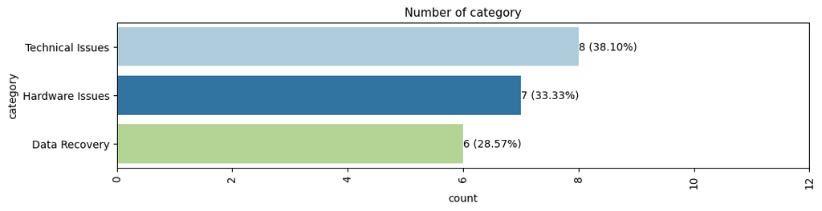

```python
# Display the number of tickets with regards to category
show_countplot(data = final_data, feature = 'category', figsize = (11.75, 2.5))
```

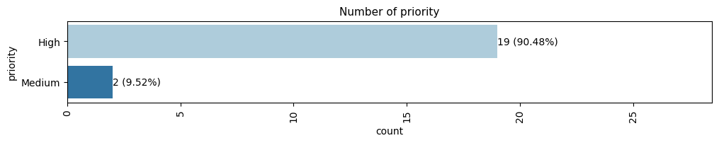

```python
# Display the number of tickets with regards to priority
show_countplot(data = final_data, feature = 'priority', figsize = (11.75, 1.5))
```

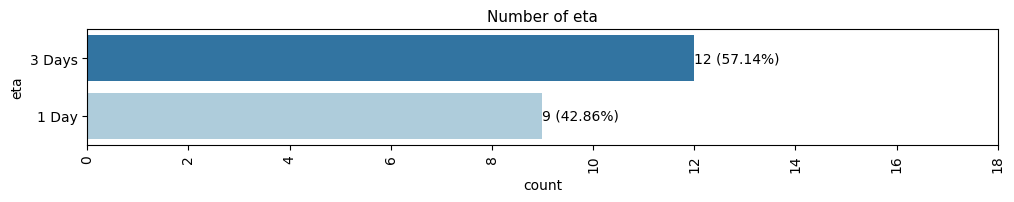

```python
# Display the number of tickets with regards to ettr
show_countplot(data = final_data, feature = 'eta', figsize = (11.75, 1.5))
```

```python
final_data['category'].value_counts()
```

| category | count |
| --- | --- |
| Technical Issues | 8 |
| Hardware Issues | 7 |
| Data Recovery | 6 |

**dtype:** int64

```python
final_data["priority"].value_counts()
```

| priority | count |
| --- | --- |
| High | 19 |
| Medium | 2 |

**dtype:** int64

```python
final_data["eta"].value_counts()
```

| eta | count |
| --- | --- |
| 3 Days | 12 |
| 1 Day | 9 |

**dtype:** int64

Let's dive in a bit deeper here.

```python
final_data.groupby(['category', 'eta']).support_tick_id.count()
```

| category | eta | support_tick_id |
| --- | --- | --- |
| Data Recovery | 1 Day | 1 |
|  | 3 Days | 5 |
| Hardware Issues | 1 Day | 2 |
|  | 3 Days | 5 |
| Technical Issues | 1 Day | 6 |
|  | 3 Days | 2 |

**dtype:** int64

```python
final_data.groupby(['priority', 'eta']).support_tick_id.count()
```

| priority | eta | support_tick_id |
| --- | --- | --- |
| High | 1 Day | 9 |
|  | 3 Days | 10 |
| Medium | 3 Days | 2 |

**dtype:** int64

```python
final_data.groupby(['category', 'priority']).support_tick_id.count()
```

| category | priority | support_tick_id |
| --- | --- | --- |
| Data Recovery | High | 6 |
| Hardware Issues | High | 6 |
|  | Medium | 1 |
| Technical Issues | High | 7 |
|  | Medium | 1 |

**dtype:** int64

```python
# Displaying first 5 rows of final_data generated by model.
final_data.head()
```

|  | support_tick_id | support_ticket_text | category | tags | priority | eta | Response |
| --- | --- | --- | --- | --- | --- | --- | --- |
| 0 | ST2023-006 | My internet connection has significantly slowe... | Technical Issues | [Connection Issues, Internet, Slow Connection] | High | 1 Day | {"response": "Dear Valued Customer,\n\nWe apo... |
| 1 | ST2023-007 | Urgent help required! My laptop refuses to sta... | Hardware Issues | [Hardware] | High | 1 Day | {"response": "Dear Valued Customer,\n\nWe are... |
| 2 | ST2023-008 | I've accidentally deleted essential work docum... | Data Recovery | [Data Loss] | High | 1 Day | {"response": "Dear Valued Customer,\n\nWe are... |
| 3 | ST2023-009 | Despite being in close proximity to my Wi-Fi r... | Technical Issues | [Wifi, Connection Issues] | Medium | 3 Days | {"response": "Dear Valued Customer,\n\nWe apo... |
| 4 | ST2023-010 | My smartphone battery is draining rapidly, eve... | Hardware Issues | [Battery] | Medium | 3 Days | {"response": "Dear Valued Customer,\n\nWe're ... |

**Observations:**

## Business Specific Output

```python
# Example of code showing potential of model for business specific tailored output.
i = 0
final_data['response_new'] = ''
while i < len(final_data['Response']):
  if "[Your Company]" in final_data['Response'][i]:
    final_data['response_new'][i] = final_data['Response'][i].replace("[Your Company]", "Actual Business Name")
  elif "[Company Name]" in final_data['Response'][i]:
    final_data['response_new'][i] = final_data['Response'][i].replace("[Company Name]", "Actual Business Name")
  else:
    final_data['response_new'][i] = final_data['Response'][i]
  i += 1
```

```python
# Example of business specific output text.
final_data['response_new'][0]
```

[output not shown]

## **Actionable Insights and Recommendations**

# Actionable Insights and Recommendations

**1. Company-Specific Context:**

**Observation:**

Outputs generated by the model become more accurate and relevant when prompts include specific information about the company. Tailoring inputs to the unique aspects of the business results in more precise and actionable outputs.

**Recommendation:**

Integrate detailed company-specific information into the model prompts to improve the contextual accuracy of the responses.

**2. Customization of Outputs:**

**Observation:**

The model’s outputs can be further tailored to meet the specific needs of the business. Customization can be done by refining prompts at the input stage or by adjusting the outputs post-generation.

**Recommendation:**

Continuously refine prompts and outputs to ensure that the model aligns with evolving business needs, potentially automating common adjustments to save time.

**3. Category Flexibility:**

**Observation:**

The model's output categories can be expanded or modified to better align with the specific types of support offered by the business, ensuring relevance and comprehensive coverage.

**Recommendation:**

Regularly review and update the model’s categorization framework to match the changing landscape of business operations and customer needs.

**4. Priority Bias:**

**Observation:**

The model tends to assign higher priority levels to tasks, which may not always align with the business’s actual capacity and availability to provide solutions.

**Recommendations:**

Adjust the model’s priority settings to reflect the business’s true operational priorities, ensuring that resources are allocated efficiently and urgent tasks are correctly identified.

**5. ETA Adjustments:**

**Observation:**

The model typically assigns an ETA of 1 to 3 days for resolving issues, which may not always reflect the actual support availability or complexity of the tasks.

**Recommendation:**

Customize the ETA settings based on realistic support timelines within the business, ensuring that the model’s outputs are both achievable and aligned with customer expectations.

**6. Issue Resolution Timelines:**

**Observation:**

The model estimates that technical issues can generally be resolved more quickly, while hardware issues and data recovery tasks may require more time. This aligns well with real-world scenarios and can inform resource allocation strategies.

# Recommendations:

Use these insights to plan and allocate resources effectively, ensuring that teams are prepared for varying resolution timelines. Recommendations:

**1.Fine-Tuning for Specific Business:**

- Action: Customize the model by embedding your business name and other relevant specifics into the prompts and responses. This enhances the relevance and personalization of the outputs.
- Benefit: Improves customer satisfaction through tailored interactions and more accurate support resolutions.

**2.Priority Adjustments:**

- Action: Modify the model’s priority levels to accurately reflect the business’s operational capabilities and current workload.
- Benefit: Ensures that urgent issues are handled promptly without overwhelming the support team.

**3.ETA Customization:**

- Action: Adjust the estimated time of arrival (ETA) for resolving support tickets to align with the actual timeframes needed by the business, taking into account task complexity and resource availability.
- Benefit: Increases the reliability of the model’s predictions and helps manage customer expectations effectively.

**4.Response Formatting:**

- Action: Review the need for formatting code (such as \n) in the model’s output. Depending on how responses are delivered, this code may need to be removed to maintain clarity and professionalism in customer communications.
- Benefit: Ensures that output formatting is consistent with the company’s communication standards, enhancing customer experience.

**5.Pre-Implementation Review:**

- Action: Conduct a thorough review of the model’s outputs using real-world data before full-scale implementation. This will confirm that the model meets business standards and performs as expected.
- Benefit: Reduces the risk of errors during deployment and ensures that the model delivers value from day one.

Power Ahead